# Bayes- Homework#1

Shyni David

2/28/2019

```r
 #install.packages("bayesm")
library(bayesm)
library(tidyverse)
```

Understanding breg()

```r
## simulate data
if(nchar(Sys.getenv("LONG_TEST")) != 0) {R=1000} else {R=10}
set.seed(66)
n = 100
X = cbind(rep(1,n), runif(n)); beta = c(1,2)
y = X %*% beta + rnorm(n)


## set prior
betabar = c(0,0)
A = diag(c(0.05, 0.05))

## make draws from posterior
betadraw1 = matrix(double(R*2), ncol = 2)
for (rep in 1:R) {betadraw1[rep,] = breg(y,X,betabar,A)}

betadraw1
```

```
##            [,1]     [,2]
##  [1,] 0.7979646 2.557394
##  [2,] 0.7660312 2.798510
##  [3,] 0.7707956 2.632640
##  [4,] 0.9096752 2.585905
##  [5,] 0.8772739 2.499192
##  [6,] 0.5453302 2.767655
##  [7,] 0.8602982 2.686363
##  [8,] 0.8830408 2.546383
##  [9,] 1.0629332 1.962561
## [10,] 0.8323963 2.532277
```

```r
## summarize draws
mat = apply(betadraw1, 2, quantile, probs=c(0.01, 0.05, 0.50, 0.95, 0.99))
mat
```

```
##          [,1]     [,2]
## 1%  0.5651933 2.010858
## 5%  0.6446456 2.204045
## 50% 0.8463473 2.571649
## 95% 0.9939671 2.784626
## 99% 1.0491400 2.795733
```

```r
beta
```

```
## [1] 1 2
```

```r
mat = rbind(beta,mat); rownames(mat)[1] = "beta"
print(mat)
```

```
##           [,1]     [,2]
## beta 1.0000000 2.000000
## 1%   0.5651933 2.010858
## 5%   0.6446456 2.204045
## 50%  0.8463473 2.571649
## 95%  0.9939671 2.784626
## 99%  1.0491400 2.795733
```

```r
## simulate data
if(nchar(Sys.getenv("LONG_TEST")) != 0) {R=1000} else {R=10}
set.seed(66)
n = 100
X = cbind(rep(1,n), runif(n), runif(n), runif(n), runif(n))
beta <-  c(1:5)
sigsq <- 4
y = X %*% beta + rnorm(n, 0, sd = sqrt(sigsq))
```

2. Plot the data

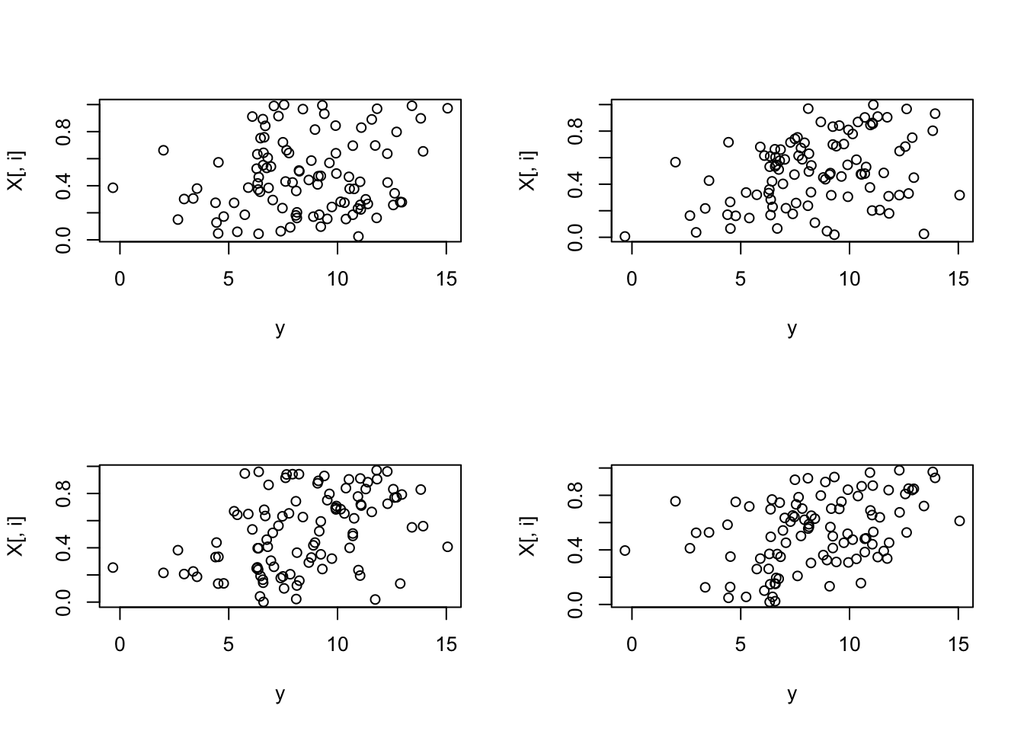

```r
nxvar = 4
par(mfcol=c(2,2))   #multiple figure layout by column
for (i in 2:(nxvar+1)){
plot(y,X[,i])
}
```

3.3. Write a regression function from scratch

```r
myreg = function(y,X) {
#purpose :compute least square regression
#arguement : y-vector of dep var, X- array of indep vars
#output : list containing lsq coefficients and standard errors

bhat=chol2inv(chol(t(X)%*%X))%*%t(X)%*% y
 yhat=X%*%bhat
 resid=y-yhat
 ybar=mean(y)
 SST=sum((y-ybar)^2)
 SSE=sum((y-yhat)^2)
 SSR=sum((yhat-ybar)^2)
 Rsq=SSR/SST
 sigma=SSE/(length(y)-ncol(X))
 stderror=sqrt(sigma)
 covb <- sigma*chol2inv(chol(t(X)%*%X))
 seb = sqrt(diag(covb))
 tstat=bhat/seb
 list(bhat=bhat, yhat=yhat, resid=resid, ybar=ybar, SST=SST, SSE=SSE,  SSR=SSR, Rsq=Rsq, stderror=stderror, seb=seb, tstat=tstat)
}
```

4. Call your function from the command prompt: > out=myreg(y,X)

```r
set.seed(66)
out1 <- myreg(y, X)
out1$bhat
```

```
##          [,1]
## [1,] 1.385260
## [2,] 2.497172
## [3,] 3.190121
## [4,] 3.853396
## [5,] 4.443149
```

```r
out1$yhat[1:5]
```

```
## [1]  7.540010 11.935342  7.240629  5.823360  9.267018
```

```r
out1$resid[1:5]
```

```
## [1] -0.4632470 -0.8418244  1.5544979  0.5063779 -7.2672857
```

```r
out1$ybar
```

```
## [1] 8.468559
```

```r
out1$SST
```

```
## [1] 821.5321
```

```r
out1$SSE
```

```
## [1] 449.1447
```

```r
out1$SSR
```

```
## [1] 372.3874
```

```r
out1$Rsq
```

```
## [1] 0.453284
```

```r
out1$stderror
```

```
## [1] 2.174359
```

```r
out1$seb
```

```
## [1] 0.8494793 0.8058601 0.7862141 0.8569062 0.8583908
```

```r
out1$tstat
```

```
##          [,1]
## [1,] 1.630717
## [2,] 3.098766
## [3,] 4.057573
## [4,] 4.496871
## [5,] 5.176138
```

```r
#Test with lm
set.seed(66)
df1 <- cbind(y, X)
df <- as_tibble(df1)
colnames(df) <- c("y", "X1", "X2", "X3", "X4", "X5")
model = lm(y~ X2+X3+X4+X5, data = df)
summary(model)
```

```
##
## Call:
## lm(formula = y ~ X2 + X3 + X4 + X5, data = df)
##
## Residuals:
##     Min      1Q  Median      3Q     Max
## -7.2673 -1.2219 -0.0161  1.4610  6.0040
##
## Coefficients:
##             Estimate Std. Error t value Pr(>|t|)
## (Intercept)   1.3853     0.8495   1.631 0.106261
## X2            2.4972     0.8059   3.099 0.002556 **
## X3            3.1901     0.7862   4.058 0.000102 ***
## X4            3.8534     0.8569   4.497 1.95e-05 ***
## X5            4.4431     0.8584   5.176 1.26e-06 ***
## ---
## Signif. codes:  0 '***' 0.001 '**' 0.01 '*' 0.05 '.' 0.1 ' ' 1
##
## Residual standard error: 2.174 on 95 degrees of freedom
## Multiple R-squared:  0.4533, Adjusted R-squared:  0.4303
## F-statistic: 19.69 on 4 and 95 DF,  p-value: 7.879e-12
```

```r
#compare myreg() bhat with lm bhat
out1$bhat
```

```
##          [,1]
## [1,] 1.385260
## [2,] 2.497172
## [3,] 3.190121
## [4,] 3.853396
## [5,] 4.443149
```

```r
model$coefficients
```

```
## (Intercept)          X2          X3          X4          X5
##    1.385260    2.497172    3.190121    3.853396    4.443149
```

The results for coefficients and Standard error matches

5. A list structure is a very good way to store panel data. Each cross-sectional unit can be a different element in the list. Panel data can be simply a list of lists. This allows for a different number of observations per panel unit as well as even different variables. To develop some familiarity with this structure, this problem will ask you to read in some panel data and perform regressions on each unit, returning an array of regression coefficients.

The dataset “cheese” in bayesm contains 5555 observations of data across 88 different U.S. retailers (try the command “?cheese”). Get a feel for the data by issuing the commands:

```r
data(cheese)
dim(cheese)
```

```
## [1] 5555    4
```

```r
cheese[1:10,]
```

```
##                    RETAILER VOLUME       DISP    PRICE
## 1       LOS ANGELES - LUCKY  21374 0.16200000 2.578460
## 2      LOS ANGELES - RALPHS   6427 0.12411257 3.727867
## 3        LOS ANGELES - VONS  17302 0.10200000 2.711421
## 4        CHICAGO - DOMINICK  13561 0.02759109 2.651206
## 5           CHICAGO - JEWEL  42774 0.09061273 1.986674
## 6            CHICAGO - OMNI   4498 0.00000000 2.386616
## 7       HOUSTON - KROGER CO   6834 0.04901897 2.481124
## 8        HOUSTON - RANDALLS   3764 0.00000000 3.428268
## 9  PITTSBURGH - GIANT EAGLE   5112 0.30850000 2.538341
## 10   DETROIT - FARMER JACKS   6676 0.13771179 2.562163
```

Create a list of lists from the data frame. Each element (Retailer) in the list should be a list of the form (y=y, X=X), where y is log(volume) and X contains two independent variables (display, price) and an intercept. Then, obtain regression estimates for the first ten retailers by using the “example” section of the “?cheese” help file.

Substitute your function in place of “lsfit” and check to see if you get the same answer.

Use myreg()

```r
## example of processing for use with rhierLinearModel

  retailer = levels(cheese$RETAILER)
  nreg = 10
  nvar = 3
  regdata = NULL
  for (reg in 1:nreg) {
    y = log(cheese$VOLUME[cheese$RETAILER==retailer[reg]])
    iota = c(rep(1,length(y)))
    X = cbind(iota, cheese$DISP[cheese$RETAILER==retailer[reg]],
      log(cheese$PRICE[cheese$RETAILER==retailer[reg]]))
    regdata[[reg]] = list(y=y, X=X)
  }
  Z = matrix(c(rep(1,nreg)), ncol=1)
  nz = ncol(Z)



  ## run each individual regression and store results
  lscoef = matrix(double(nreg*nvar), ncol=nvar)
  for (reg in 1:nreg) {
    coef = myreg(regdata[[reg]]$y, regdata[[reg]]$X)$bhat
    if (var(regdata[[reg]]$X[,2])==0) {
      lscoef[reg,1]=coef[[1]]
      lscoef[reg,3]=coef[[2]]
    }
    else {lscoef[reg,]=coef[,1]}
  }
  lscoef
```

```
##            [,1]       [,2]      [,3]
##  [1,] 11.150185  0.9182245 -4.302126
##  [2,] 10.153727  1.1524049 -1.653589
##  [3,] 10.025171 -0.9110710 -2.061616
##  [4,] 13.300028  0.1566367 -3.727223
##  [5,] 11.324441  3.0852216 -2.288623
##  [6,] 10.951031  9.5769255 -2.928705
##  [7,] 10.456949 -0.2088132 -1.378306
##  [8,]  8.432159  0.1518841 -1.044676
##  [9,] 10.770488  0.8528471 -2.661849
## [10,] 15.839792 26.8724498 -8.972018
```

Using lsfit()

```r
## example of processing for use with rhierLinearModel

  retailer = levels(cheese$RETAILER)
  nreg = 10
  nvar = 3
  regdata = NULL
  for (reg in 1:nreg) {
    y = log(cheese$VOLUME[cheese$RETAILER==retailer[reg]])
    iota = c(rep(1,length(y)))
    X = cbind( iota, cheese$DISP[cheese$RETAILER==retailer[reg]],
      cheese$PRICE[cheese$RETAILER==retailer[reg]])
    regdata[[reg]] = list(y=y, X=X)
  }
  Z = matrix(c(rep(1,nreg)), ncol=1)
  nz = ncol(Z)


  ## run each individual regression and store results
  lscoef = matrix(double(nreg*nvar), ncol=nvar)

  for (reg in 1:nreg) {
    coef = lsfit(regdata[[reg]]$X, regdata[[reg]]$y, intercept=FALSE)$coef
    if (var(regdata[[reg]]$X[,2])==0) {
      lscoef[reg,1]=coef[1]
      lscoef[reg,3]=coef[2]
    }
    else {lscoef[reg,]=coef}
  }

lscoef
```

```
##            [,1]       [,2]       [,3]
##  [1,] 11.203414  1.0529514 -1.5954785
##  [2,] 10.073978  1.2236886 -0.5750989
##  [3,] 10.080346 -0.9128060 -0.7788002
##  [4,] 12.451652  0.1621413 -1.0866270
##  [5,] 10.794715  3.0719032 -0.6599166
##  [6,] 10.311400  9.4375028 -0.8592436
##  [7,] 10.638604 -0.2136613 -0.5774671
##  [8,]  8.608739  0.1459960 -0.4527776
##  [9,] 11.092847  0.8816309 -1.1042482
## [10,] 16.866151 26.9197205 -3.7003890
```